# Analysis Code

2025-03-19

## 1. Install and Load Packages

```r
#Install relevant packages if you do not have them. I use these ones:
library(psych)
library(truncnorm)
library(dplyr)
library(car)
library(effectsize)
library(ggplot2)
library(tibble)
```

## 2. Simulate the Data

### Simulate all the participant responses and dependent variables

```r
# Read in the data (in a normal case)

#Set seed for replication
set.seed(1)

# Simulating data (for our case)
  nsubj = 128 #based on power analysis
  nPerGroup = 64
  nConds = 2
  nTrials <- 10
  mindfulness <- nPerGroup
  NOmindfulness <- nPerGroup
  condLabels = c("mindfulness", "NOmindfulness") #One group watches the mindfulness meditation video, the other group does not.

# Create participant IDs
  Participant <- rep(1:nsubj, each = nTrials)

# Create condition labels
  Condition <- rep(rep(condLabels, each = nPerGroup), each = nTrials) # 64 participants per condition

# Simulate unique RT per trial depending on condition, truncate at 0 because people cannot have negative RT
  reaction_timeDIST <- c(
    rtruncnorm(nPerGroup * nTrials, a = 0, mean = 700, sd = 200),  # Mindfulness
    rtruncnorm(nPerGroup * nTrials, a = 0, mean = 900, sd = 350)   # NOmindfulness
  )

# Simulate accuracy per group
  mindfulnessdistAccuracy <- rnorm(nPerGroup, mean = 95, sd = 10)
  NOmindfulnessdistAccuracy <- rnorm(nPerGroup, mean = 90, sd = 10)

# Round to nearest 10 and clip between 60 and 100
  mindfulnessdistAccuracy <- pmin(pmax(round(mindfulnessdistAccuracy / 10) * 10, 0), 100)
  NOmindfulnessdistAccuracy <- pmin(pmax(round(NOmindfulnessdistAccuracy / 10) * 10, 0), 100)

# Repeat each accuracy value across 10 trials
  accuracyM <- rep(mindfulnessdistAccuracy, each = nTrials)
  accuracyNM <- rep(NOmindfulnessdistAccuracy, each = nTrials)
  accuracyDIST <- c(accuracyM, accuracyNM)

# Simulate response and correct response
  responses <- sample(c("triangle", "circle", "star"), nsubj * nTrials, replace = TRUE)
  correct_responses <- sample(c("triangle", "circle", "star"), nsubj * nTrials, replace = TRUE)

# Put everything into a dataframe
  df <- data.frame(
    Participant = Participant,
    Condition = Condition,
    trial_number = rep(1:nTrials, nsubj),
    response = responses,
    correct_response = correct_responses,
    reaction_time = reaction_timeDIST,
    avgAccuracy = accuracyDIST,
    stringsAsFactors = TRUE
  )

  head(df)
```

```
##   Participant   Condition trial_number response correct_response reaction_time
## 1           1 mindfulness            1   circle         triangle      574.7092
## 2           1 mindfulness            2   circle         triangle      736.7287
## 3           1 mindfulness            3 triangle           circle      532.8743
## 4           1 mindfulness            4 triangle             star     1019.0562
## 5           1 mindfulness            5     star         triangle      765.9016
## 6           1 mindfulness            6 triangle           circle      535.9063
##   avgAccuracy
## 1         100
## 2         100
## 3         100
## 4         100
## 5         100
## 6         100
```

## 3. Data Cleaning

In a real situation, some data cleaning may be required. The following cases would require exclusion:

- If a participant spends an unrealistic amount of time on a trial (ex. longer than 2-3 seconds)
- If a participant gets every single trial incorrect (0% Accuracy)
- If a participant’s accuracy indicates random or intentionally incorrect responses (>50% accuracy)

## 4. Data Analysis

### (a) Lets do some **descriptive statistics**.

```r
#get summary/descriptive stats
  describe(df[, c("reaction_time", "avgAccuracy")])
```

```
##               vars    n   mean     sd median trimmed    mad   min     max
## reaction_time    1 1280 798.96 309.63 772.54  783.68 285.31 19.95 1969.51
## avgAccuracy      2 1280  90.47   8.28  90.00   90.88  14.83 70.00  100.00
##                 range  skew kurtosis   se
## reaction_time 1949.56  0.50     0.40 8.65
## avgAccuracy     30.00 -0.33    -0.88 0.23
```

```r
#get mean RT and Accuracy per condition
  df %>%
    group_by(Condition) %>%
    summarise(
      mean_RT = mean(reaction_time, na.rm = TRUE),
      sd_RT = sd(reaction_time, na.rm = TRUE),
      mean_accuracy = mean(avgAccuracy, na.rm = TRUE),
      sd_accuracy = sd(avgAccuracy, na.rm = TRUE)
    )
```

```
## # A tibble: 2 × 5
##   Condition     mean_RT sd_RT mean_accuracy sd_accuracy
##   <fct>           <dbl> <dbl>         <dbl>       <dbl>
## 1 mindfulness      702.  201.          93.1        7.27
## 2 NOmindfulness    896.  364.          87.8        8.39
```

```r
#save participant means for later tests
  participant_meanRT <- df %>%
    group_by(Participant, Condition) %>%
    summarise(mean_RT = mean(reaction_time, na.rm = TRUE), .groups = "drop")

  participant_accuracy <- df %>%
    group_by(Participant, Condition) %>%
    summarise(mean_accuracy = mean(avgAccuracy, na.rm = TRUE), .groups = "drop")
```

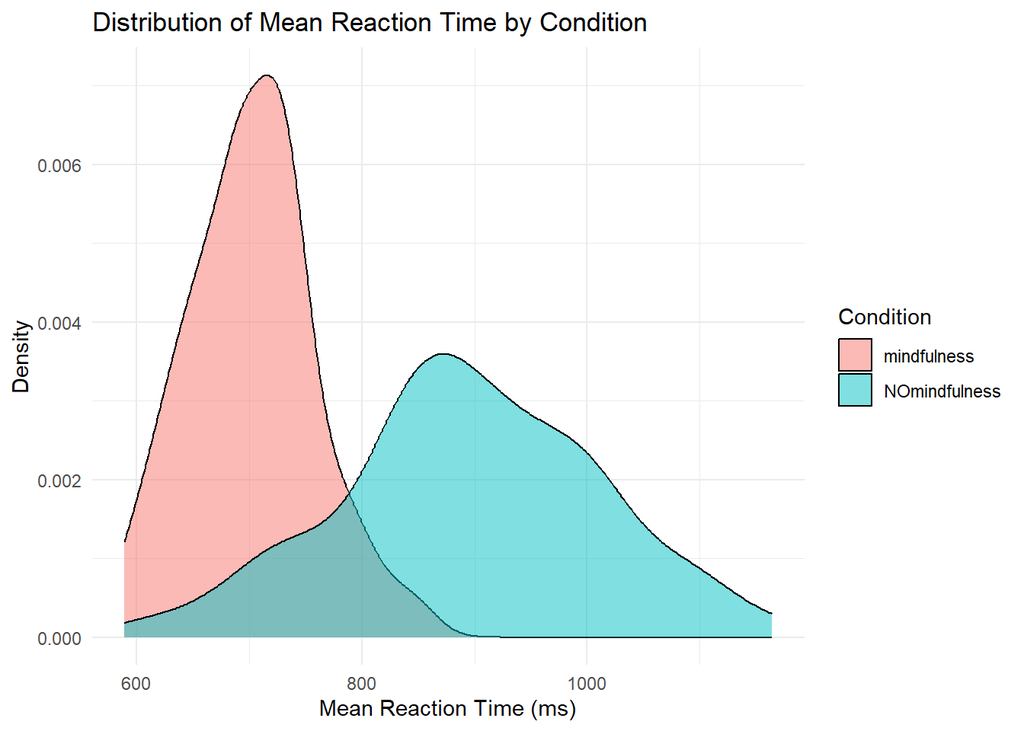

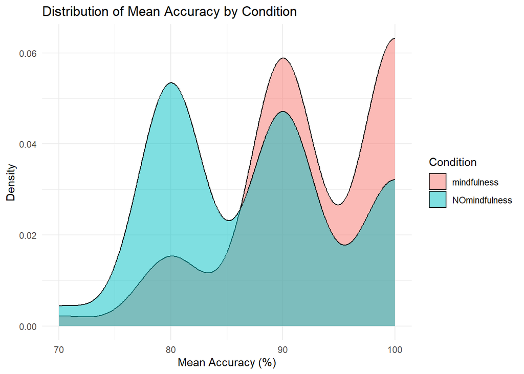

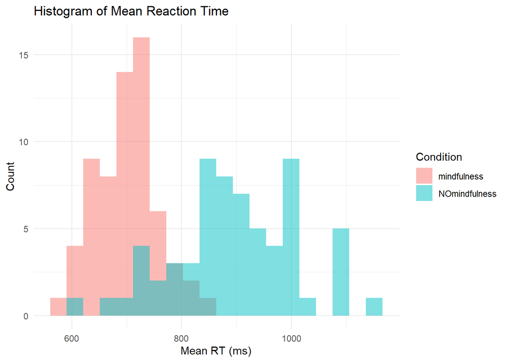

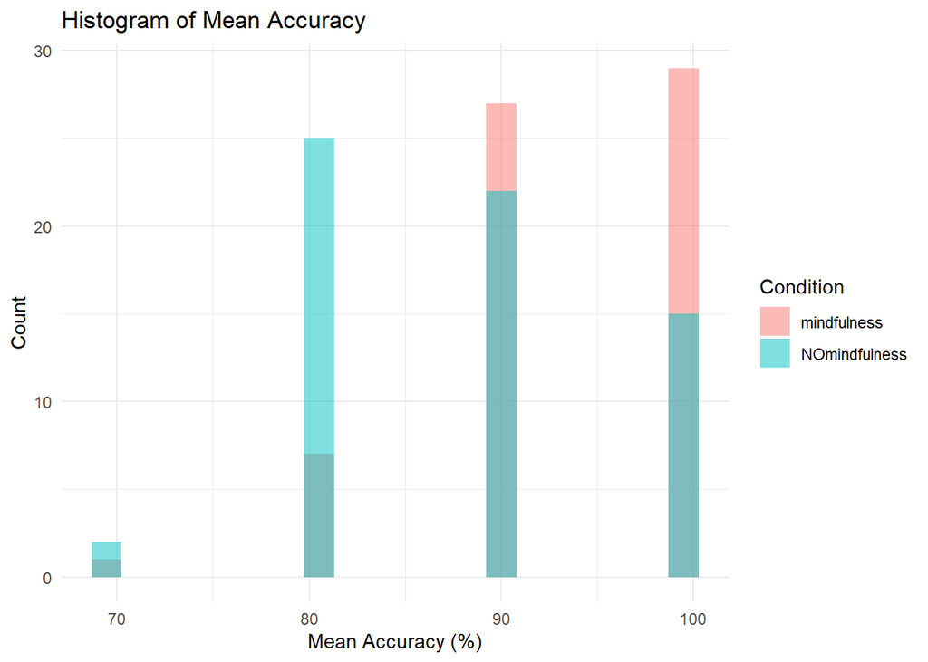

#### **Key results:**

- Mindfulness Condition
  - mean Reaction Time = 701.6738 ms
  - standard deviation Reaction Time = 201.4728 ms
  - mean % Accuracy = 93.1250
  - standard deviation % Accuracy = 7.267524
- Non-mindfulness Condition
  - mean Reaction Time = 896.2458 ms
  - standard deviation Reaction Time = 363.7926 ms
  - mean % Accuracy = 87.8125
  - standard deviation % Accuracy = 8.385984

### (b) Lets move on to the **inferential** statistics.

#### Hypothesis - Reaction time

- **H1:** If mindfulness improves attentional skills, participants who complete the mindfulness task will have a lower reaction time than participants who do not complete the mindfulness task.
- **H0:** If mindfulness worsens or has no effect on attentional skills, participants who complete the mindfulness task will have a higher or equal visual search task accuracy than participants who do not complete the mindfulness task.

#### Hypothesis - Accuracy

- **H1:** If mindfulness improves attentional skills, participants who complete the mindfulness task will have a higher visual search task accuracy than participants who do not complete the mindfulness task.
- **H0:** If mindfulness worsens or has no effect on attentional skills, participants who complete the mindfulness task will have a lower or equal visual search task accuracy than participants who do not complete the mindfulness task.

#### **We must first assess if the data meets the assumptions of a t-test.**

```r
# Test RT and Accuracy for normality for both conditions (Shapiro-Wilk Test)
shapiro.test(participant_meanRT$mean_RT[participant_meanRT$Condition == "mindfulness"]) #p=0.789
```

```
##
##  Shapiro-Wilk normality test
##
## data:  participant_meanRT$mean_RT[participant_meanRT$Condition == "mindfulness"]
## W = 0.98795, p-value = 0.789
```

```r
shapiro.test(participant_meanRT$mean_RT[participant_meanRT$Condition == "NOmindfulness"]) #p=0.8465
```

```
##
##  Shapiro-Wilk normality test
##
## data:  participant_meanRT$mean_RT[participant_meanRT$Condition == "NOmindfulness"]
## W = 0.98911, p-value = 0.8465
```

```r
shapiro.test(participant_accuracy$mean_accuracy[participant_accuracy$Condition == "mindfulness"]) #p < 0.001
```

```
##
##  Shapiro-Wilk normality test
##
## data:  participant_accuracy$mean_accuracy[participant_accuracy$Condition == "mindfulness"]
## W = 0.78239, p-value = 2.419e-08
```

```r
shapiro.test(participant_accuracy$mean_accuracy[participant_accuracy$Condition == "NOmindfulness"]) #p < 0.001
```

```
##
##  Shapiro-Wilk normality test
##
## data:  participant_accuracy$mean_accuracy[participant_accuracy$Condition == "NOmindfulness"]
## W = 0.84301, p-value = 1.013e-06
```

```r
# Test RT and Accuracy for homogeneity of variance for both conditions (Levene's Test)
# Levene's Test for Reaction Time
leveneTest(mean_RT ~ Condition, data = participant_meanRT) #p<0.001
```

```
## Levene's Test for Homogeneity of Variance (center = median)
##        Df F value    Pr(>F)
## group   1  23.471 3.651e-06 ***
##       126
## ---
## Signif. codes:  0 '***' 0.001 '**' 0.01 '*' 0.05 '.' 0.1 ' ' 1
```

```r
# Levene's Test for Accuracy
leveneTest(mean_accuracy ~ Condition, data = participant_accuracy) #p=0.317
```

```
## Levene's Test for Homogeneity of Variance (center = median)
##        Df F value Pr(>F)
## group   1  1.0071 0.3175
##       126
```

#### **t-test Assumption Tests Summary:**

**1. Shapiro-Wilk Test Results:**

- Reaction time is normally distributed in both conditions (p>0.05)
- % Accuracy is NOT normally distributed in both conditions (p<0.05). This makes sense because the data is negatively skewed and most participants have 90-100% accuracy.

**2. Levene’s Test Results:**

- Reaction time has an unequal variance across conditions (p < 0.001).
- % Accuracy has an equal variance across conditions (p = 0.317).

**3. Assumption of independence:**

- This test meets the assumption of independence because:
  - Each participant is randomly sorted into either condition
  - We use one data point per participant to represent their trials (mean RT and accuracy instead of individual trial values)

#### **What test do we use?**

**Reaction time:** Normality ✓, Homogeneity of Variance ✖, Assumption of Independence ✓

**Test: Welch’s t-test**

**Accuracy:** Normality ✖, Homogeneity of Variance ✓, Assumption of Independence ✓

**Test: Wilcoxon test**

#### **Now we can conduct the appropriate hypothesis tests.**

```r
# One-tailed Welch's t-test for mean RT
t.test(mean_RT ~ Condition, data = participant_meanRT, var.equal = FALSE, alternative = "less") #p<0.001, CI=(-∞, -168.17)
```

```
##
##  Welch Two Sample t-test
##
## data:  mean_RT by Condition
## t = -12.247, df = 90.928, p-value < 2.2e-16
## alternative hypothesis: true difference in means between group mindfulness and group NOmindfulness is less than 0
## 95 percent confidence interval:
##       -Inf -168.1703
## sample estimates:
##   mean in group mindfulness mean in group NOmindfulness
##                    701.6738                    896.2458
```

```r
# Wilcoxon test for mean accuracy
wilcox.test(mean_accuracy ~ Condition, data = participant_accuracy, alternative = "greater") #W = 2767, p<.001
```

```
##
##  Wilcoxon rank sum test with continuity correction
##
## data:  mean_accuracy by Condition
## W = 2767, p-value = 0.0001394
## alternative hypothesis: true location shift is greater than 0
```

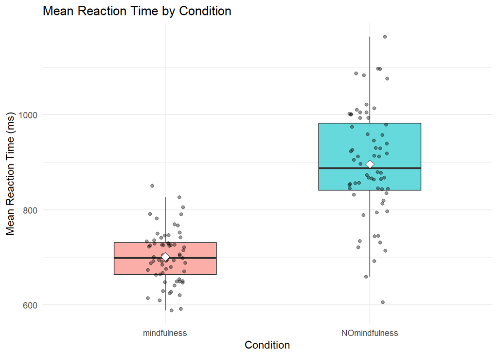

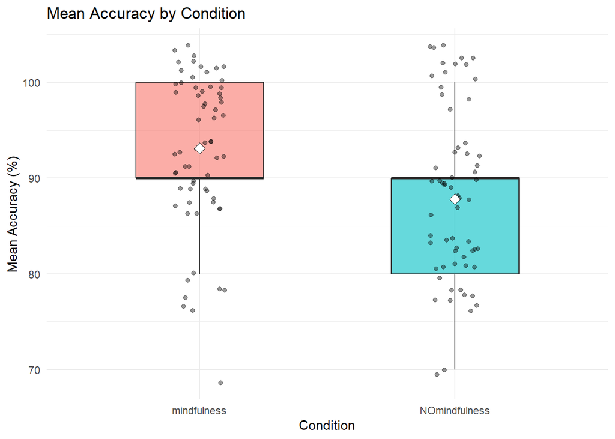

#### **Now we can conduct post-hoc effect size tests.**

```r
#Conduct Cohen's d test for mean RT
cohens_d(mean_RT ~ Condition, data = participant_meanRT) #d = -2.16, 95% CI [-2.60, -1.72]
```

```
## Cohen's d |         95% CI
## --------------------------
## -2.16     | [-2.60, -1.72]
##
## - Estimated using pooled SD.
```

```r
#Conduct Cohen's d test for mean Accuracy
cohens_d(mean_accuracy ~ Condition, data = participant_accuracy) #d = 0.67, 95% CI [0.31, 1.03],
```

```
## Cohen's d |       95% CI
## ------------------------
## 0.67      | [0.31, 1.03]
##
## - Estimated using pooled SD.
```

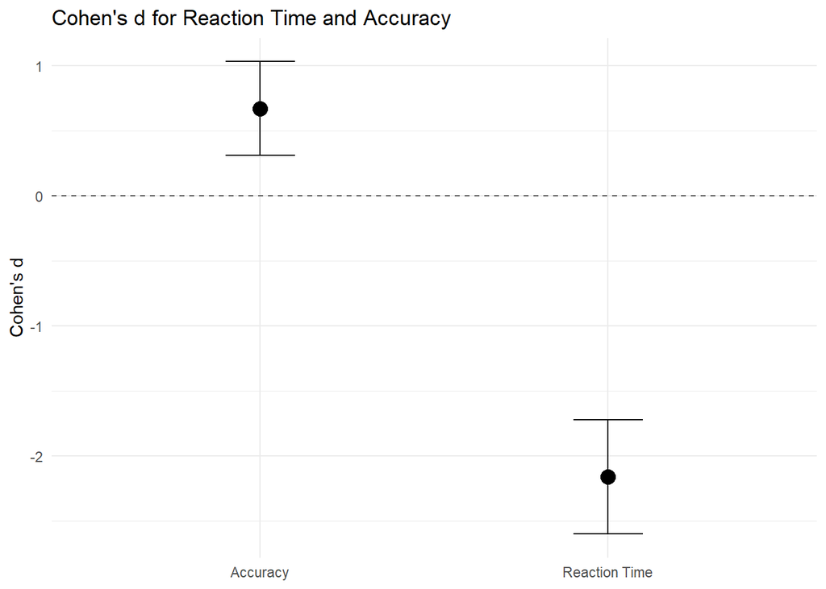

## 5. Results

### **Hypothesis Tests Summary:**

**Welch’s t-test results for Reaction Time:** participants in the mindfulness condition (M = 701.67 ms) responded **significantly faster** than those in the NOmindfulness condition (M = 896.25 ms), p<0.001. *We do not fail to reject the null hypothesis.*

**Wilcoxon Test results for Accuracy:** participants in the mindfulness condition had **significantly higher** accuracy scores than those in the NOmindfulness condition, p<0.001. *We do not fail to reject the null hypothesis.*

### **Effect Size**

**Reaction Time**: There was a large effect of condition on reaction time (d = -2.16), indicating that participants in the mindfulness condition responded significantly faster than those in the NOmindfulness condition.

**Accuracy**: There was a moderate to large effect of condition on accuracy (d = 0.67), indicating that participants in the mindfulness condition performed more accurately than those in the NOmindfulness condition.